# Abstract

Given the escalating concerns surrounding climate change and the ever-increasing demand for electricity, the generation of low-carbon electricity has assumed utmost importance in curbing greenhouse gas emissions and fostering a cleaner and more sustainable future. This report presents a comprehensive analysis of low-carbon electricity generation, focusing on its history, current trends, and future prospects.

The analysis begins by examining quantitatively the historical context of low-carbon electricity generation, tracing its origins and evolution over time and by proposing insights on different sources and world areas.

Next, the report delves into the current trends and status of low-carbon electricity generation. By exploiting a tailored yet simple measure, the Green Score, it provides a detailed overview of various sources such as nuclear, solar, wind, and hydropower, along with their contributions to the global energy mix.

Finally, various models with different transformations on the data are proposed, in order to find the best performing ones: models’ coefficients are analyzed to learn the impact of the different independent variables on variables that measure pollution and the adoption of different renewable energy sources in the countries over the last two decades.

# Chapter 1: Obtaining data

We could not find a single dataset containing all the information of interest. Thus, the project’s first step is merging multiple datasets into one. The primary one is the *Energy dataset* by Our World in Data (from now onwards referred to as “OWID”) [1], which contains various time series for each world country regarding energy and electricity production and consumption.

```r
# Import the libraries
library(dplyr)
library(tidyr)
library(ggplot2)
library(viridis)
library(rworldmap)
library(glmnet)
library(readxl)
library(gridExtra)
library(corrplot)
library(knitr)
```

```r
# Import the Energy dataset
main = read.csv("datasets//Total_energy_data.csv")
```

We then merge the following datasets into it:

- *GDP (constant 2015 US$)* by World Bank [2], which contains the time series of the GDP in each country from 1960 to 2021, measured in constant 2015 USA dollars.
- *Land Area* by OWID [3], which contains the time series of the land area of each country from 1961 to 2021, measured in squared kilometers;
- *Agricultural land* by OWID [4], which contains the time series of the share of land area used for agriculture in each country from 1961 to 2018;
- *Urbanization rate* by OWID [5], which contains the time series of the share of people living in urban areas in each country from 1960 to 2020;
- *Human Development Index* by OWID [6], which contains the time series of the HDI for each country from 1990 to 2021;
- *Death rate from air pollution* by OWID [7], which after filtering contains the time series of the number of deaths from outdoor particulate matter per 100,000 population in each country from 1990 to 2019;
- *Coal proved reserves* by OWID [8], which contains the reserves of coal in each country in 2021, measured in tonnes;
- *Oil proved reserves* by OWID [9], which contains the reserves of oil in each country in 2020, measured in tonnes;
- *Natural gas proved reserves* by OWID [10], which contains the time series of the reserves of natural gas in each country from 1980 to 2020;
- *Uranium proved reserves* by OECD [11], which contains uranium reserves in each country in 2019, measured in tonnes.

Merging presents three critical issues listed below, together with the implemented solutions.

1. Time series are recorded for different years. We tackled this problem by merging through left join: all the rows of the *Energy dataset* are included, while rows from the other datasets are included if there is a match; otherwise, a NA value is added. In order to perform correctly the left join, we need to remove the countries in the *Energy dataset* without an ISO code. This is the case for some semi-autonomous territories inside of a country (e.g., Wake Island), countries that no longer exist (e.g., Yugoslavia), and country groupings (e.g., OPEC countries). Therefore, we decide to remove those observations.
2. Coal, oil, and uranium reserves are stationary values, as time series for those variables are not publicly available. Therefore, we approached the issue by considering the reserves fixed through time, as it does not affect the quality of the analyses.
3. *GDP (constant 2015 US$)* dataset contains a column for each year, while the other time series datasets format the years using a specific variable. Therefore, we modify the structure of *GDP* to fit the others’.

```r
# Delete units from "main" without an ISO code
main = main[main$iso_code!='',]

# Creation of a function able to automatically join datasets from OWID
join_owid = function(main_data, secondary_dataset_link){
  place_data = read.csv(paste(secondary_dataset_link))
  main_data = left_join(main_data, select(place_data, -c("Entity")),
                 by = c("iso_code" = "Code", "year" = "Year"))
  rm(place_data)
  return(main_data)
}

# Import and merging of OWID variables country area, HDI and urbanization rate
main = join_owid(main, "datasets//country_areas.csv")
main = join_owid(main, "datasets//human_development_index.csv")
main = join_owid(main, "datasets//urbanization_rate.csv")

# Import, selection and merging of deaths from air pollution
 death_rates = read.csv("datasets//death_rates_from_air_pollution.csv")[, c(2,3,5)]
 colnames(death_rates) = c("Code", "Year", "particulate_pollution")
 main = left_join(main, death_rates,
                  by = c("iso_code" = "Code", "year" = "Year"))
rm(death_rates)

# Import and merging share of land for for agricultural use
main = join_owid(main, "datasets//share_of_land_area_used_for_agriculture.csv")


# Import, filtering and merging of coal proved reserves
coal_res = read.csv("datasets//coal_proved_reserves.csv")
coal_res = coal_res[coal_res$Year!="2020",]
colnames(coal_res) = c("Entity", "Code", "Year", "coal_reserves_2021")
main = left_join(main, select(coal_res, -c("Entity","Year")),
                 by = c("iso_code" = "Code"))
rm(coal_res)

# Import and merging oil proved reserves
main = join_owid(main, "datasets//oil_proved_reserves.csv")

# Import and merging of uranium reserves
uranium_res = read.csv("datasets//uranium_proved_reserves.txt", sep = "\t")
colnames(uranium_res) = c("V1","V2", "uranium_reserves_2019", "V4")
uranium_res$uranium_reserves_2019 = as.numeric(gsub(",","",uranium_res$uranium_reserves_2019))
uranium_res$V1 = sub(".","",uranium_res$V1)
main = left_join(main, select(uranium_res, -c("V2", "V4")),
                 by = c("country" = "V1"))
rm(uranium_res)

# Import and merging natural gas proved reserves
main = join_owid(main, "datasets//natural_gas_proved_reserves.csv")

# Import the GDP dataset
gdp = read_excel("datasets//gdp_constant_2015_dollars.xlsx")[,4:66]
# Structure modification
colnames(gdp) = c("code", 1960:2021)
gdp = gather(gdp, key = "year", value = "gdp", -code)
gdp$year = as.integer(gdp$year)
# Merging
main = left_join(main, gdp, by = c("iso_code" = "code", "year" = "year"))
rm(gdp)
```

# Chapter 2: Data pre-processing

In this section, we present the pre-processing activities performed.

1. **Units selection**, computed over the *Energy dataset*. Already partially computed and explained in the previous section, in this phase we also removed two regions with too many missing values: Antarctica and Western Sahara.
2. **Feature selection**, computed over the *Energy dataset*. From the original 129 variables, we kept only 36 relevant for the analyses.
3. **Feature renaming**, computed over *main*, as the features merged to the *Energy dataset* have inconvenient names.
4. **Feature addition**, computed over *main* in paragraph 4.3. The new categorical variable groups the world countries into six macroregions.
5. **Cleaning NA values**, computed over *main*. It consists of the substitution of NA values for reserves data to 0 and of ‘..’ to NA for GDP.

```r
# 1. Units selection: remove Antarctica and Western Sahara
main = filter(main, iso_code != "ATA", iso_code != "ESH")

# 2. Feature selection
main = select(main, -c("gdp.x", "biofuel_cons_change_pct",
                       "biofuel_cons_change_twh", "biofuel_cons_per_capita",
                       "biofuel_elec_per_capita", "biofuel_consumption",
                       "biofuel_electricity", "biofuel_share_elec",
                       "biofuel_share_energy", "coal_cons_change_pct",
                       "coal_cons_change_twh", "coal_cons_per_capita",
                       "coal_elec_per_capita", "coal_prod_change_pct",
                       "coal_prod_change_twh", "coal_prod_per_capita",
                       "coal_consumption", "coal_share_energy",
                       "energy_cons_change_pct", "energy_per_capita",
                       "energy_per_gdp", "electricity_share_energy",
                       "fossil_cons_change_pct", "fossil_cons_change_twh",
                       "fossil_elec_per_capita", "fossil_fuel_consumption",
                       "fossil_share_energy", "gas_cons_change_pct",
                       "gas_cons_change_twh", "gas_elec_per_capita",
                       "gas_prod_change_pct", "gas_prod_change_twh",
                       "gas_prod_per_capita", "gas_consumption",
                       "gas_share_energy", "hydro_cons_change_pct",
                       "hydro_cons_change_twh", "hydro_elec_per_capita",
                       "fossil_energy_per_capita", "hydro_energy_per_capita",
                       "hydro_consumption", "hydro_share_energy",
                       "low_carbon_cons_change_pct", "low_carbon_cons_change_twh",
                       "low_carbon_elec_per_capita", "low_carbon_energy_per_capita",
                       "low_carbon_consumption", "low_carbon_share_energy",
                       "net_elec_imports_share_demand", "nuclear_cons_change_pct",
                       "nuclear_cons_change_twh", "nuclear_elec_per_capita",
                       "nuclear_energy_per_capita", "nuclear_consumption",
                       "nuclear_share_energy", "oil_prod_per_capita",
                       "gas_energy_per_capita", "oil_elec_per_capita",
                       "oil_prod_change_pct", "oil_prod_change_twh",
                       "oil_consumption", "oil_share_energy",
                       "other_renewable_exc_biofuel_electricity", "other_renewables_cons_change_pct",
                       "other_renewables_cons_change_twh", "other_renewables_elec_per_capita",
                       "other_renewables_elec_per_capita_exc_biofuel",
                       "other_renewables_energy_per_capita",
                       "other_renewables_share_elec_exc_biofuel", "other_renewable_consumption",
                       "other_renewables_share_energy", "per_capita_electricity",
                       "renewables_cons_change_pct", "renewables_cons_change_twh",
                       "renewables_elec_per_capita", "renewables_energy_per_capita",
                       "renewables_consumption", "renewables_share_energy",
                       "solar_cons_change_pct", "solar_cons_change_twh",
                       "solar_elec_per_capita", "solar_consumption",
                       "solar_share_energy", "wind_cons_change_pct",
                       "wind_cons_change_twh", "wind_consumption",
                       "wind_share_energy", "solar_energy_per_capita",
                       "wind_elec_per_capita", "wind_energy_per_capita",
                       "oil_cons_change_pct", "oil_cons_change_twh",
                       "oil_energy_per_capita"))

# 3. Feature renaming
colnames(main) = c(colnames(main[,1:36]), "land_area", "hdi", "urbaniz_rate",
                           "particulate_pollution", "agri_land_rate",
                           "coal_reserves_2021", "oil_reserves_2020",
                           "uranium_reserves_2019","gas_reserves", "gdp")

# 4. Cleaning NA and 0 values
main = main %>% mutate(
  oil_reserves_2020 = coalesce(oil_reserves_2020, 0),
  uranium_reserves_2019 = coalesce(uranium_reserves_2019, 0),
  gas_reserves = coalesce(gas_reserves, 0),
  coal_reserves_2021 = coalesce(coal_reserves_2021, 0))

main = mutate(main, gdp = na_if(gdp, ".."))
main$gdp = as.numeric(main$gdp)
```

# Chapter 3: Exploratory analyses

## 3.1 Global exploratory analyses

The first step of exploratory analysis is getting a summary of our dataset and describing each feature.

```r
summary(main)
```

```
##    country               year        iso_code           population
##  Length:16338       Min.   :1900   Length:16338       Min.   :1.833e+03
##  Class :character   1st Qu.:1944   Class :character   1st Qu.:1.286e+06
##  Mode  :character   Median :1983   Mode  :character   Median :5.683e+06
##                     Mean   :1973                      Mean   :2.688e+07
##                     3rd Qu.:2003                      3rd Qu.:1.717e+07
##                     Max.   :2022                      Max.   :1.426e+09
##                                                       NA's   :65
##  carbon_intensity_elec coal_electricity  coal_production    coal_share_elec
##  Min.   :   0.0        Min.   :   0.00   Min.   :    0.00   Min.   :  0.00
##  1st Qu.: 266.7        1st Qu.:   0.00   1st Qu.:    0.00   1st Qu.:  0.00
##  Median : 488.6        Median :   0.00   Median :    0.00   Median :  0.00
##  Mean   : 439.3        Mean   :  46.78   Mean   :  163.40   Mean   : 13.83
##  3rd Qu.: 629.6        3rd Qu.:   7.66   3rd Qu.:   12.35   3rd Qu.: 19.52
##  Max.   :1000.0        Max.   :5339.14   Max.   :23651.39   Max.   :100.00
##  NA's   :11776         NA's   :11033     NA's   :3447       NA's   :11056
##  electricity_demand electricity_generation energy_cons_change_twh
##  Min.   :   0.00    Min.   :   0.000       Min.   :-1978.438
##  1st Qu.:   0.93    1st Qu.:   1.155       1st Qu.:   -0.083
##  Median :   8.21    Median :  12.140       Median :    0.378
##  Mean   :  99.07    Mean   : 109.935       Mean   :   12.128
##  3rd Qu.:  46.96    3rd Qu.:  57.050       3rd Qu.:    6.700
##  Max.   :8466.32    Max.   :8484.020       Max.   : 2796.320
##  NA's   :11297      NA's   :10446          NA's   :7078
##  fossil_electricity fossil_share_elec gas_electricity   gas_production
##  Min.   :   0.00    Min.   :  0.00    Min.   :   0.00   Min.   :   0.000
##  1st Qu.:   0.30    1st Qu.: 38.65    1st Qu.:   0.00   1st Qu.:   0.000
##  Median :   3.65    Median : 72.70    Median :   0.38   Median :   0.000
##  Mean   :  76.33    Mean   : 64.67    Mean   :  23.93   Mean   :  96.610
##  3rd Qu.:  34.47    3rd Qu.: 96.67    3rd Qu.:  13.10   3rd Qu.:   7.249
##  Max.   :5623.99    Max.   :100.00    Max.   :1624.17   Max.   :9342.032
##  NA's   :10927      NA's   :11056     NA's   :11033     NA's   :3280
##  gas_share_elec    greenhouse_gas_emissions hydro_electricity
##  Min.   :  0.000   Min.   :   0.00          Min.   :   0.000
##  1st Qu.:  0.000   1st Qu.:   0.21          1st Qu.:   0.010
##  Median :  1.124   Median :   1.68          Median :   1.490
##  Mean   : 18.181   Mean   :  46.68          Mean   :  18.392
##  3rd Qu.: 27.882   3rd Qu.:  15.49          3rd Qu.:   9.482
##  Max.   :100.000   Max.   :4618.32          Max.   :1321.710
##  NA's   :11056     NA's   :11647            NA's   :9173
```

[output cut: 49 more lines]

```
##  Min.   :  2.48        Min.   : 0.263   Min.   :0.000e+00   Min.   :0.000e+00
##  1st Qu.: 21.91        1st Qu.:18.678   1st Qu.:0.000e+00   1st Qu.:0.000e+00
##  Median : 35.03        Median :37.621   Median :0.000e+00   Median :0.000e+00
##  Mean   : 45.28        Mean   :37.257   Mean   :6.845e+09   Mean   :4.251e+08
##  3rd Qu.: 59.42        3rd Qu.:55.376   3rd Qu.:0.000e+00   3rd Qu.:0.000e+00
##  Max.   :205.58        Max.   :90.556   Max.   :2.489e+11   Max.   :4.144e+10
##  NA's   :10471         NA's   :7104
##  uranium_reserves_2019  gas_reserves            gdp
##  Min.   :      0       Min.   :0.000e+00   Min.   :2.156e+07
##  1st Qu.:      0       1st Qu.:0.000e+00   1st Qu.:5.099e+09
##  Median :      0       Median :0.000e+00   Median :2.179e+10
##  Mean   :  46446       Mean   :3.221e+11   Mean   :2.748e+11
##  3rd Qu.:   6100       3rd Qu.:0.000e+00   3rd Qu.:1.296e+11
##  Max.   :2049400       Max.   :3.789e+13   Max.   :2.053e+13
##                                            NA's   :7579
```

10 of them are have been presented in the data obtaining step; the other 35 features, belonging to the initial energy dataset, are:

- **Year** and **Population**;
- Pollution measurements: **Carbon intensity of electricity** (which measures how many grams of CO2 are release to produce a kWh of electricity) and **Greenhouse gas emissions**;
- Overall energy and electricity measurements: **Electricity demand** (which is the amount of electricity consumed), **Electricity generation** (the amount of electricity produced), **Energy consumption change in tWh** (change in energy consumed compared to the previous year), **Net electricity imports** (electricity imported minus electricity exported for the country) and **Primary energy consumption** (Energy consumed by the country);
- Variables related to electricity consumption and production for each source: renewables, that are divided in hydro, solar, wind, other renewables; fossil, divided in coal, oil and gas; and finally low carbon, which is the aggregation of renewables with nuclear. For each source the dataset presents a variable for **electricity production** and **share of electricity production**, and for each single fossil source the **production** is also present.

The following is the distribution of units by Year:

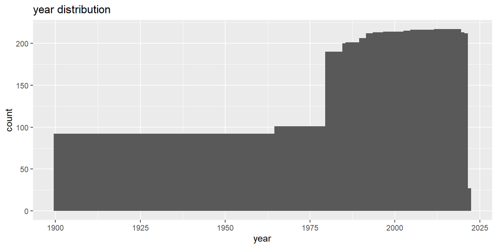

```r
ggplot(main, aes(x = year)) + geom_histogram(bins = 123) + ggtitle(paste("year distribution"))
```

## 3.2 Variable transformation

Then we explore more in depth each variable by plotting its distribution and by viewing the share of NA values, since for some years the dataset is very sparse.

However, as is already noticeable from the summaries, the data is very skewed and has many outliers. This is further shown by plotting for Population.

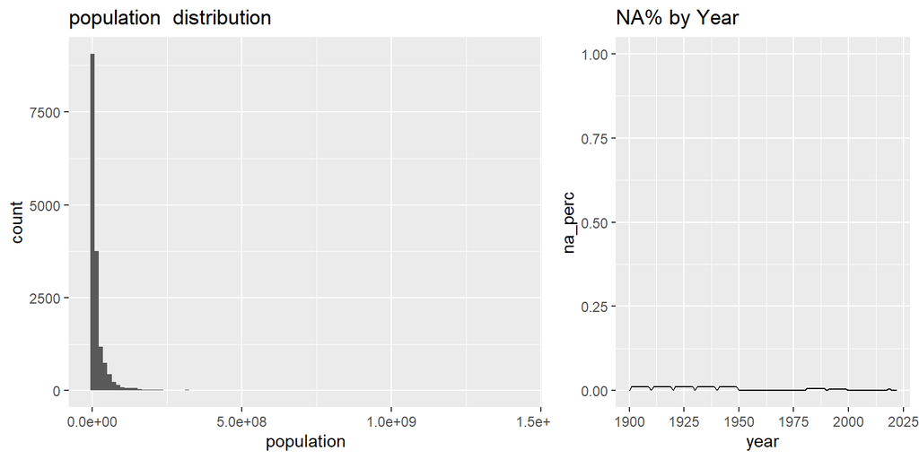

```r
i=4
i1 <- colnames(main)[i]
p11 <- ggplot(main, aes_string(x = i1)) + geom_histogram(bins = 100) + ggtitle(paste(i1, " distribution"))
nacount = main %>%
  group_by(year) %>%
  summarize(na_perc = sum(is.na(!!sym(i1)))/n())
p12 <- ggplot(nacount, aes(x = year, y = na_perc)) + geom_line() + ylim(0, 1) + ggtitle("NA% by Year")
grid.arrange(p11, p12, widths = c(0.6, 0.4), ncol = 2)
```

Also, we create a subset of our dataset containing data from a single year, 2016.

```r
cols_pc <- c(6,7,9,10,11,12,14,15,17,18,20,22,23,25,26,28,29,30,31,33,35,37,42,43,44,45,46)
cols_log <- c(4, 37, 42, 43, 44, 45, 46)

mainlog <- main %>% mutate(across(all_of(cols_pc), .fns = ~.*1000000/population))
mainlog <- mainlog %>% mutate(across(all_of(c(cols_log)), .fns = ~ log(.+1)))

#single year visualization, 2016
mainlog2016 = mainlog[mainlog$year==2016,]
```

## 3.3 Plotting function and division in groups

As we have many variables, we write a function to plot for a given variable it’s distribution, it’s distribution only for the year 2016, and it’s NA percentage by Year; the function also prints the three countries with the highest measurement for the variable in 2016.

```r
do_plots = function(i){
  i1 = colnames(mainlog)[i]
  x_min <- min(mainlog[i1], na.rm=TRUE)
  x_max <- max(mainlog[i1], na.rm=TRUE)
  x_diff <- x_max-x_min
  p11 = ggplot(mainlog, aes_string(x = i1)) + geom_histogram(bins = 25) +
    ggtitle(paste(i1, " distribution")) + xlim(x_min-x_diff/25, x_max+x_diff/25)
  p12 = ggplot(mainlog2016, aes_string(x = i1)) + geom_histogram(bins = 25) +
    ggtitle("2016 distribution") + xlim(x_min-x_diff/25, x_max+x_diff/25)
  nacount = mainlog %>%
    group_by(year) %>%
    summarize(na_perc = sum(is.na(!!sym(i1)))/n())
  p13 = ggplot(nacount, aes(x = year, y = na_perc)) + geom_line() + ylim(0, 1) +
    ggtitle("NA% by Year")
  grid.arrange(p11, p12, p13, widths = c(3,3,2), ncol = 3)
  i1_ord = mainlog2016[order(mainlog2016[i1], decreasing=TRUE),1]
  print(paste("Top three countries in 2016 for",i1,":", i1_ord[1], ",", i1_ord[2], ",", i1_ord[3]))
}
```

We can plot again for Population, and we can now see population has a log-normal distribution. For 2016 it is similarly distributed, with an overall shift to the right.

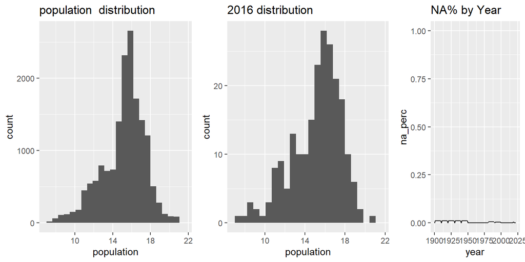

```
## [1] "Top three countries in 2016 for population : China , India , United States"
```

```r
do_plots(4)
```

To make the exploration easier and more intuitive, we divide variables into five groups, each containing: 1. Variables about the reserves; 2. Variables that regard low carbon sources; 3. Variables regarding high carbon (fossil) sources; 4. Other variables that belonged to the Energy dataset, which are variables in that dataset not about a specific source; 5. Other variables that did not belong to the Energy dataset.

```r
other_measures = c(5,17,9,10,11,22,30)
reserves = c(42,43,44,45)
ext_measures = c(37,38,39,40,41,46)
lowcarb = c(18,19,33,34,35,36,28,29,31,32,23,24,20,21)
highcarb = c(6,7,8,14,15,16,25,26,27,12,13)
```

Now we plot for each group using the function we created, and we also plot the correlation between variables inside each group.

## 3.4 Analysis on groups of variables

### 3.4.1 Analysis on Energy dataset non source specific

First, we observe the variables in the Energy dataset not specific to any source:

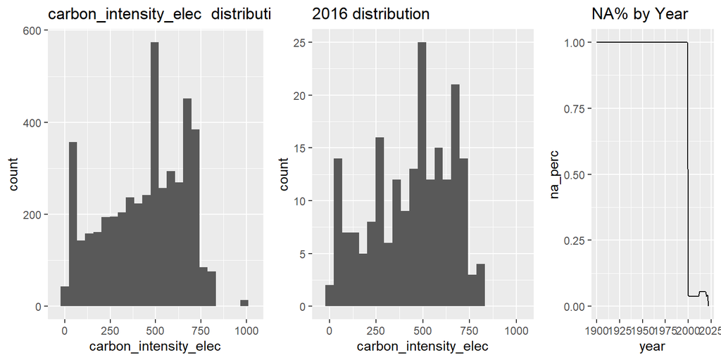

```
## [1] "Top three countries in 2016 for carbon_intensity_elec : Botswana , Comoros , Saint Pierre and Miquelon"
```

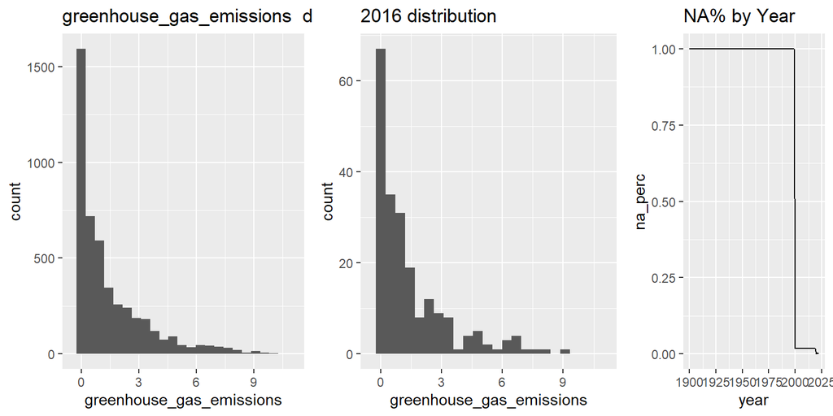

```
## [1] "Top three countries in 2016 for greenhouse_gas_emissions : Bahrain , Kuwait , Qatar"
```

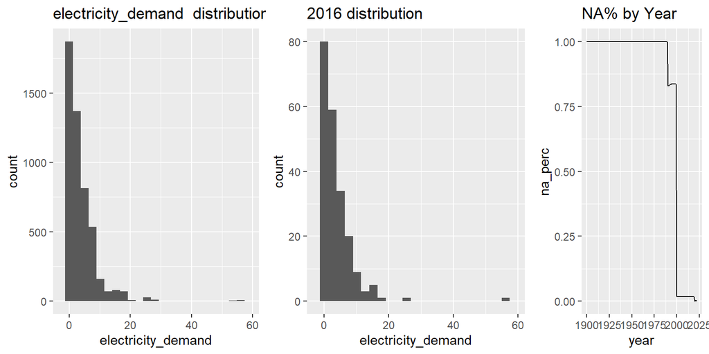

```
## [1] "Top three countries in 2016 for electricity_demand : Iceland , Norway , Bahrain"
```

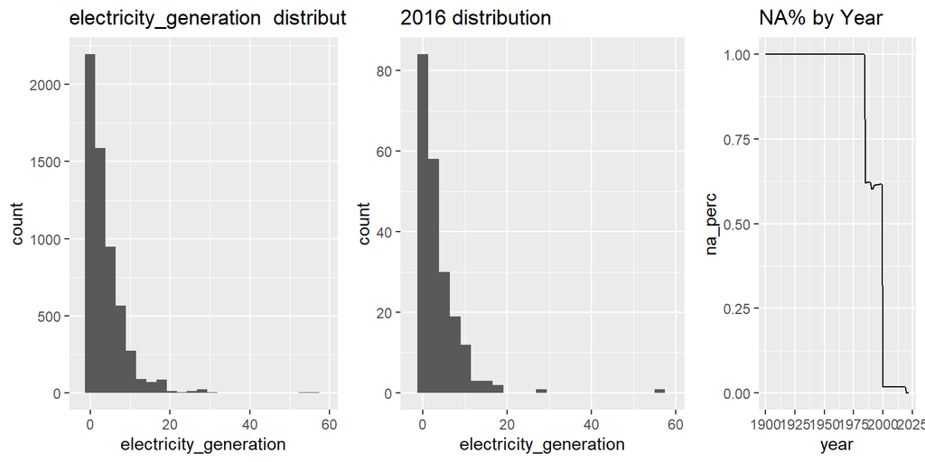

```
## [1] "Top three countries in 2016 for electricity_generation : Iceland , Norway , Bahrain"
```

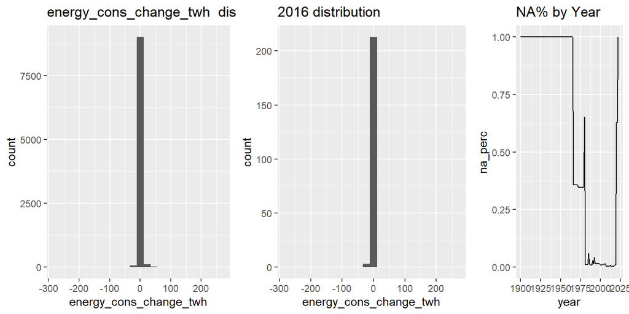

```
## [1] "Top three countries in 2016 for energy_cons_change_twh : Bermuda , Laos , Malta"
```

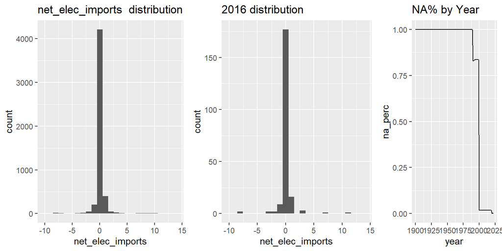

```
## [1] "Top three countries in 2016 for net_elec_imports : Luxembourg , Macao , Finland"
```

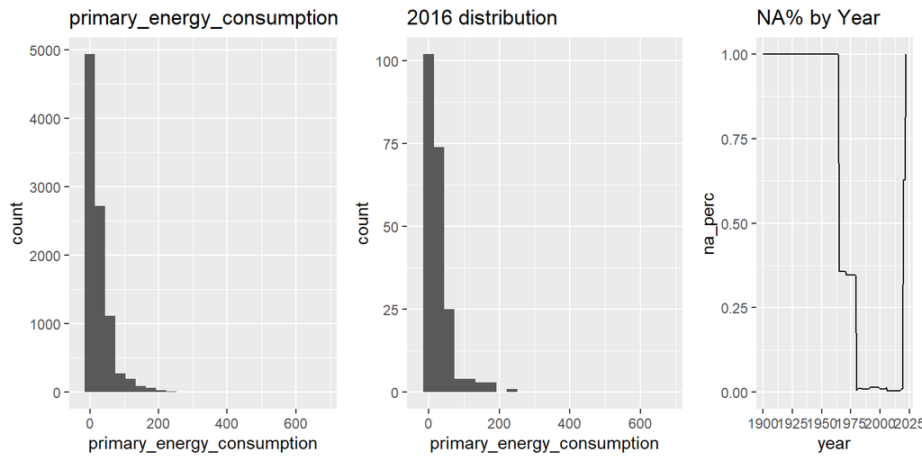

```
## [1] "Top three countries in 2016 for primary_energy_consumption : Qatar , Iceland , Netherlands Antilles"
```

```r
for (i in other_measures){
  do_plots(i)
}
```

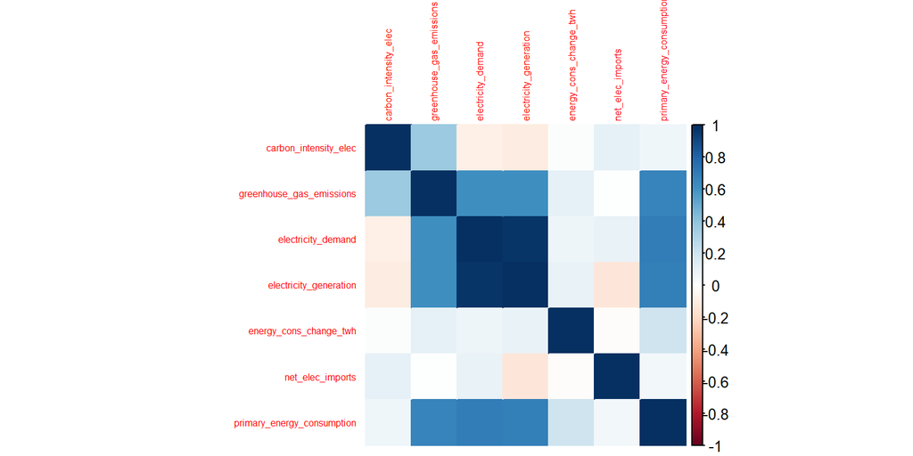

```r
corrplot(cor(mainlog[,other_measures], use="pairwise.complete.obs"), method="color", tl.cex = .5)
```

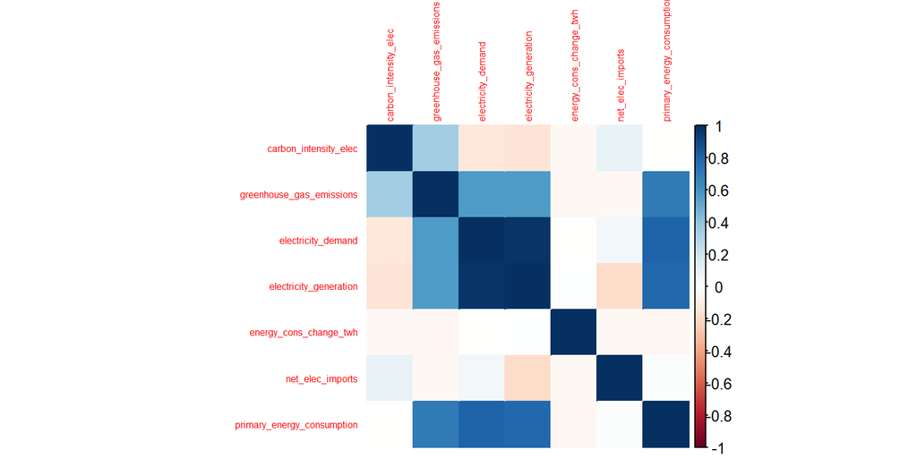

```r
corrplot(cor(mainlog2016[,other_measures], use="pairwise.complete.obs"), method="color", tl.cex = .5)
```

From the NA% plot we notice that some variables are only recorded since 2000, which is important to highlight, especially for data modeling.

There is a noticeable difference between **carbon intensity of electricity** and **greenhouse gas emissions** (even tho the two have a slight positive correlation) the first one has a distribution similar to a gaussian, with left skewing, while the second looks more like a log-gaussian, but the most important difference can be noticed in the countries with the highest measurements: carbon intensity in fact measures only the CO2 pollution from electricity, with some small countries being the highest pollutors (for each kWh), with these countries probably fully relying on coal for electricity production; greenhouse gas emissions instead consider the emissions made during energy generation, so it considers also primary energy, the contries with the highest scores are oil producers from middle east. Also **Primary energy consumption** is correlated to greenhouse gas emissions, but not to carbon intensity of electricity.

The countries with the highest **electricity demands and generation** (two measurements that are almost collinear, as expected) are rich countries that are either very cold or very hot.

### 3.4.2 Analysis on Energy dataset for fossil sources

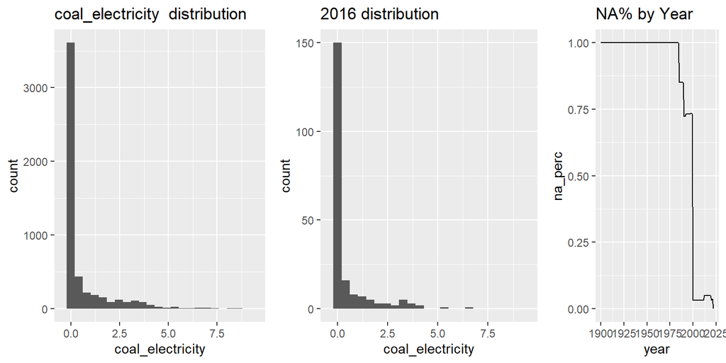

```
## [1] "Top three countries in 2016 for coal_electricity : Australia , Taiwan , South Korea"
```

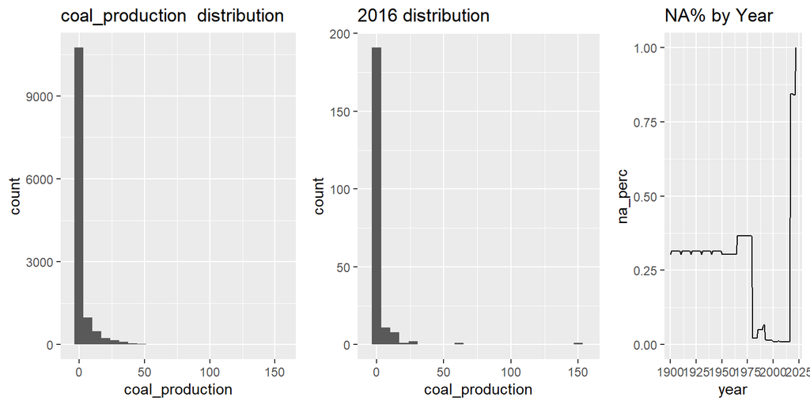

```
## [1] "Top three countries in 2016 for coal_production : Australia , Mongolia , South Africa"
```

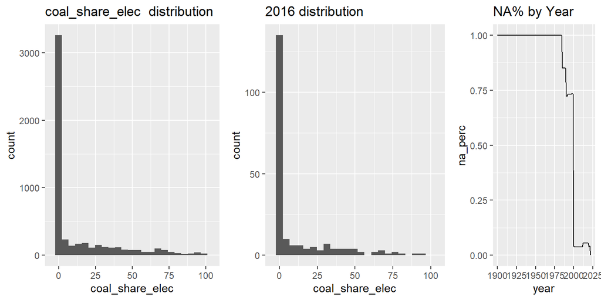

```
## [1] "Top three countries in 2016 for coal_share_elec : Mongolia , South Africa , Botswana"
```

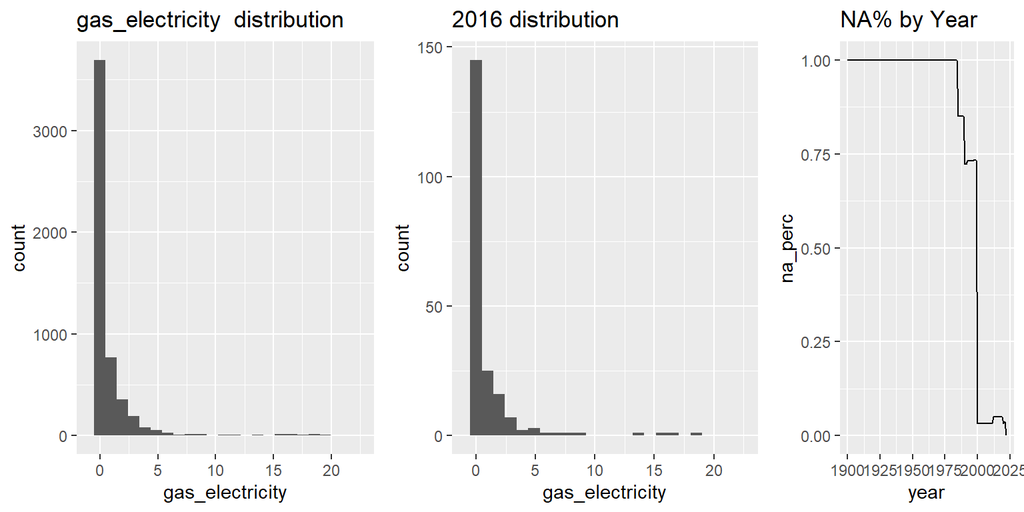

```
## [1] "Top three countries in 2016 for gas_electricity : Bahrain , Kuwait , Qatar"
```

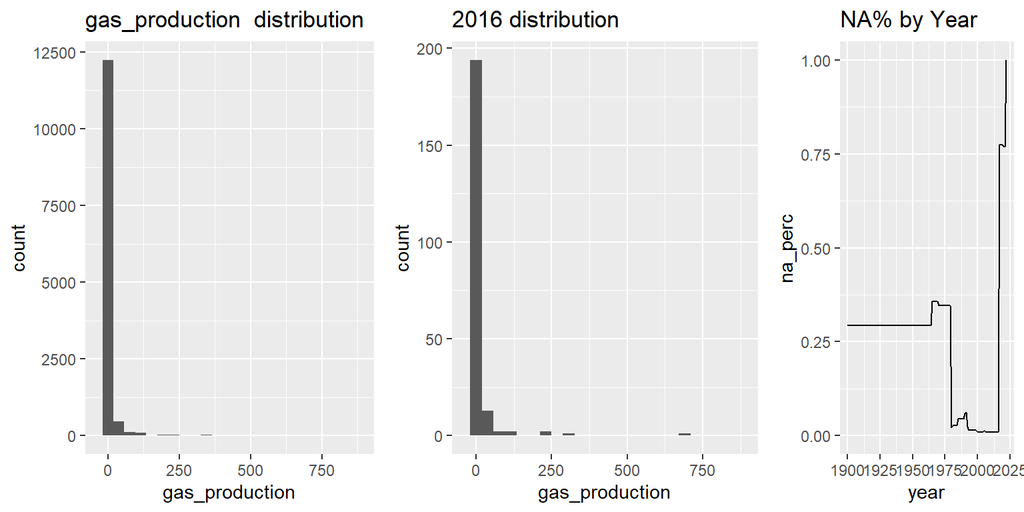

```
## [1] "Top three countries in 2016 for gas_production : Qatar , Brunei , Norway"
```

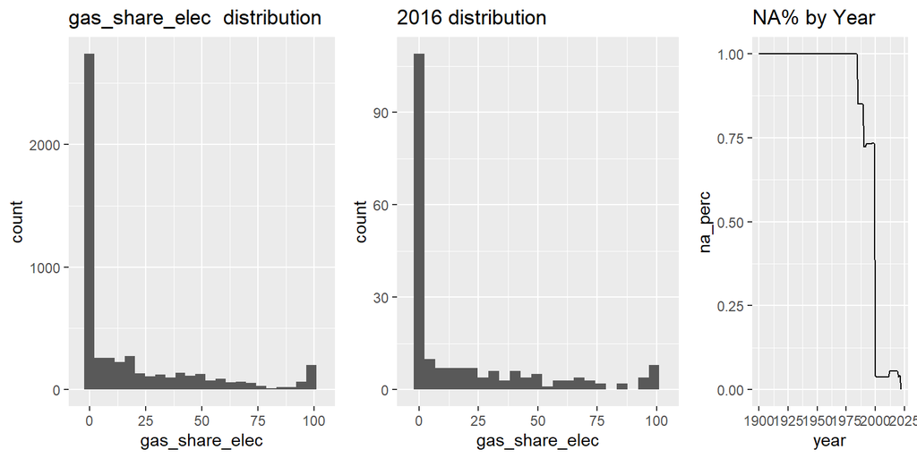

```
## [1] "Top three countries in 2016 for gas_share_elec : Macao , Oman , Kuwait"
```

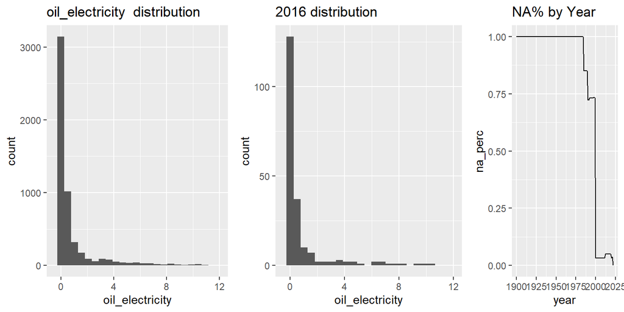

```
## [1] "Top three countries in 2016 for oil_electricity : Cayman Islands , Guam , New Caledonia"
```

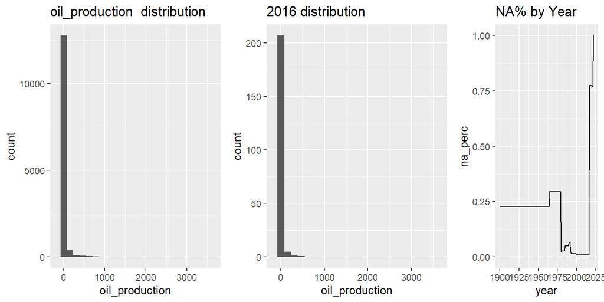

```
## [1] "Top three countries in 2016 for oil_production : Kuwait , Qatar , United Arab Emirates"
```

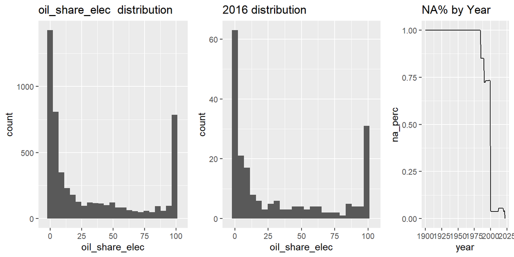

```
## [1] "Top three countries in 2016 for oil_share_elec : American Samoa , Antigua and Barbuda , Bahamas"
```

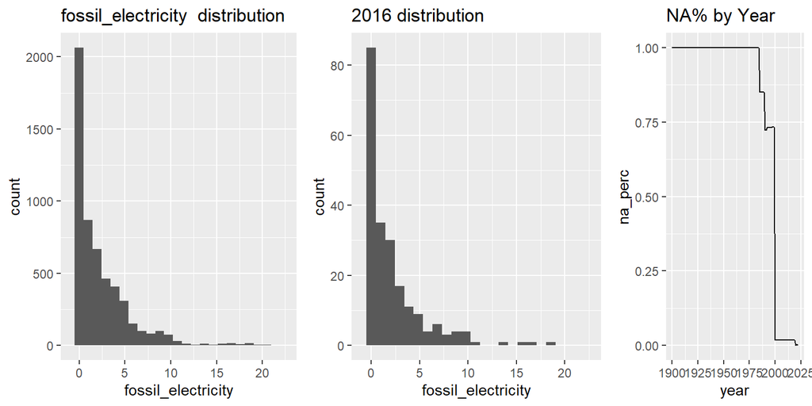

```
## [1] "Top three countries in 2016 for fossil_electricity : Bahrain , Kuwait , Qatar"
```

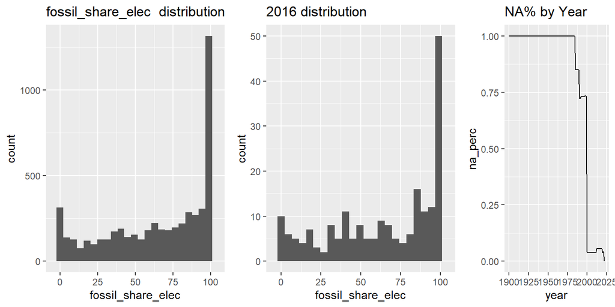

```
## [1] "Top three countries in 2016 for fossil_share_elec : American Samoa , Antigua and Barbuda , Bahamas"
```

```r
for (i in highcarb){
  do_plots(i)
}
```

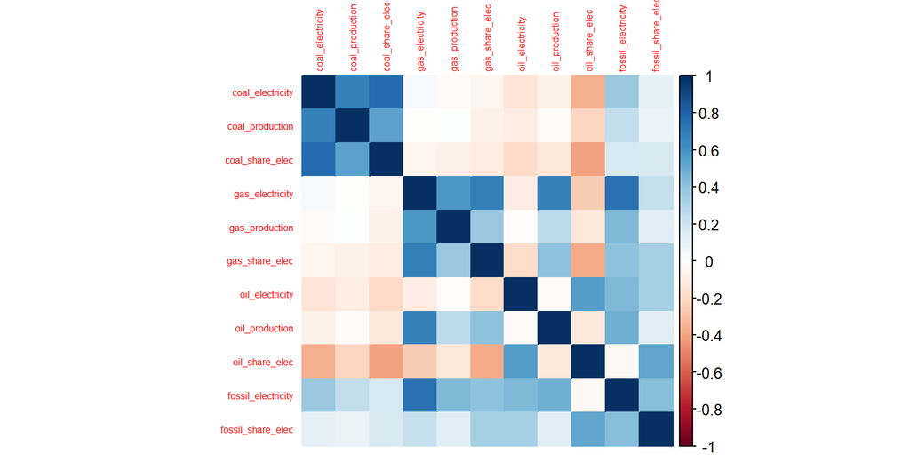

```r
corrplot(cor(mainlog[,highcarb], use="pairwise.complete.obs"), method="color", tl.cex = .5)
```

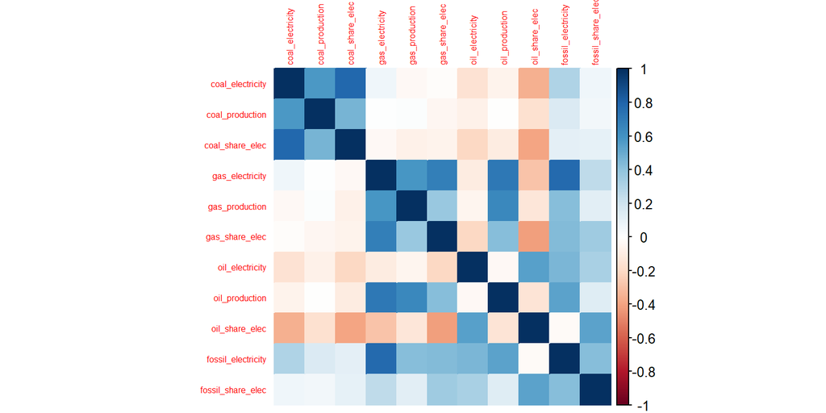

```r
corrplot(cor(mainlog2016[,highcarb], use="pairwise.complete.obs"), method="color", tl.cex = .5)
```

Moving on to fossil sources, we notice that **oil** overall is the most used source, but curiously oil **production** and **electricity** from oil are not correlated (and even have a negative correlation when considering the share of electricity). In contrast, instead **coal** and **gas** have a strong correlation, meaning countries that use them tend to be producers, while the same cannot be said for **oil**.

Comparing the graphs with all years versus 2016, we can notice a very slight decrease over time of use for all fossil sources.